# twitter_slurs

```python
import numpy as np
import pandas as pd
import os
import collections
from pandas.core.reshape.merge import merge
import matplotlib.pyplot as plt
os.chdir('C:\\Users\\ellas\\Downloads')
import nltk.corpus #Import the nltk.corpus submodule
```

```python
twitter = pd.read_csv('Ethos_Dataset_Multi_Label (2).csv', sep = ';')
twitter
```

|  | comment | violence | directed_vs_generalized | gender | race | national_origin | disability | religion | sexual_orientation |
| --- | --- | --- | --- | --- | --- | --- | --- | --- | --- |
| 0 | You should know women's sports are a joke | 0.000000 | 0.000000 | 1.000000 | 0.000000 | 0.000000 | 0.000000 | 0.000000 | 0.000000 |
| 1 | You look like Sloth with deeper Down’s syndrome | 0.000000 | 0.833333 | 0.000000 | 0.000000 | 0.000000 | 1.000000 | 0.000000 | 0.000000 |
| 2 | You look like Russian and speak like Indian. B... | 1.000000 | 0.500000 | 0.142857 | 0.142857 | 0.714286 | 0.000000 | 0.000000 | 0.000000 |
| 3 | Women deserve to be abused, I guess. | 0.666667 | 0.166667 | 1.000000 | 0.000000 | 0.000000 | 0.000000 | 0.000000 | 0.000000 |
| 4 | Women are made for making babies and cooking d... | 0.000000 | 0.000000 | 1.000000 | 0.000000 | 0.000000 | 0.000000 | 0.000000 | 0.000000 |
| ... | ... | ... | ... | ... | ... | ... | ... | ... | ... |
| 428 | All people are fucked up because of these quee... | 0.000000 | 0.000000 | 0.571429 | 0.000000 | 0.000000 | 0.000000 | 0.000000 | 0.571429 |
| 429 | Actually THIS WEIRD PEOPLE are HARMFUL! They n... | 0.000000 | 1.000000 | 0.000000 | 0.000000 | 0.333333 | 0.666667 | 0.000000 | 0.000000 |
| 430 | ABU DA BI ABA DU BA BA HAMUD! See? I’m an arab... | 0.000000 | 0.000000 | 0.000000 | 0.285714 | 0.000000 | 0.000000 | 0.857143 | 0.000000 |
| 431 | a homo? so you fuck your brother instead of yo... | 0.000000 | 0.666667 | 0.000000 | 0.000000 | 0.000000 | 0.000000 | 0.000000 | 1.000000 |
| 432 | (((They))) will be chased out of every white c... | 0.333333 | 0.000000 | 0.000000 | 0.666667 | 0.000000 | 0.000000 | 0.333333 | 0.000000 |

433 rows × 9 columns

Questions of interest

1. What percentage of these tweets are being flagged for race, national origin, violence, directed?
2. What percentage of these tweets are being flagged for intent and violence?
3. What racial/ethnic groups are being targeted in the tweets flagged for both intent and violence

```python
#Nationality:
collections.Counter(twitter.national_origin != 0)
nat = 1-229/len(twitter.national_origin)

#Race:
collections.Counter(twitter.race != 0)
rac = 1-297/len(twitter.race)

#Violence:
collections.Counter(twitter.violence != 0)
vio = 1-185/len(twitter.violence)

#Directed:
collections.Counter(twitter.directed_vs_generalized != 0)
direct = 1-194/len(twitter.violence)
```

[output not shown]

```python
#Percentage flagged for violence which have offensive nationality language
lst = []
for x in range(len(twitter.race)):
    trufal = (twitter.national_origin[x] != 0 and twitter.violence[x] != 0)
    lst.append(trufal)
collections.Counter(lst)
natvio = 86/229

#Percentage Flagged for violence which have offensive racial language
lst = []
for x in range(len(twitter.race)):
    trufal = (twitter.race[x] != 0 and twitter.violence[x] != 0)
    lst.append(trufal)
collections.Counter(lst)
racvio = 80/297

#Percentage Flagged for offensive racial language which are also violent
lst = []
for x in range(len(twitter.race)):
    trufal = (twitter.directed_vs_generalized[x] != 0 and twitter.violence[x] != 0)
    lst.append(trufal)
collections.Counter(lst)
dirvio = 146/185

#Percentage Flagged for being directed which also have offensive nationality language
lst = []
for x in range(len(twitter.race)):
    trufal = (twitter.national_origin[x] != 0 and twitter.directed_vs_generalized[x] != 0)
    lst.append(trufal)
collections.Counter(lst)
natdir = 73/229

#Percentage Flagged for being directed which also have offensive racial language
lst = []
for x in range(len(twitter.race)):
    trufal = (twitter.race[x] != 0 and twitter.directed_vs_generalized[x] != 0)
    lst.append(trufal)
collections.Counter(lst)
racdir = 70/297

#Percentage Flagged for offensive nationality language and offensive racial language
lst = []
for x in range(len(twitter.race)):
    trufal = (twitter.national_origin[x] != 0  or twitter.race[x] != 0)
    lst.append(trufal)
collections.Counter(lst)

#Percentage of nationality language and/or offensive racial language which are also violent
lst = []
for x in range(len(twitter.race)):
    trufal = ((twitter.national_origin[x] != 0  or twitter.race[x] != 0) and twitter.violence[x] != 0)
    lst.append(trufal)
collections.Counter(lst)
natracvio = 126/205

#Percentage of nationality language and/or offensive racial language which are also violent and directed
lst = []
for x in range(len(twitter.race)):
    trufal = ((twitter.national_origin[x] != 0  or twitter.race[x] != 0) and twitter.violence[x] != 0 and  twitter.directed_vs_generalized[x] != 0)
    lst.append(trufal)
collections.Counter(lst)
natracviodir = 69/205

multi= {'Natonality':nat, 'Race':rac, 'Violence': vio, 'Directed': direct,
    '%Nationality which are Violent':natvio, '%Race which are Violence':racvio,
        '%Nationality which are Directed': natdir, '%Race which are Directed':racdir,
        "%(Race or Nationality) and are violent": natracvio,
        "%(Race or Nationality) and are both violent and directed": natracviodir}
multi
```

```
{'Natonality': 0.47113163972286376,
 'Race': 0.3140877598152425,
 'Violence': 0.5727482678983833,
 'Directed': 0.5519630484988453,
 '%Nationality which are Violent': 0.37554585152838427,
 '%Race which are Violence': 0.26936026936026936,
 '%Nationality which are Directed': 0.31877729257641924,
 '%Race which are Directed': 0.2356902356902357,
 '%(Race or Nationality) and are violent': 0.6146341463414634,
 '%(Race or Nationality) and are both violent and directed': 0.33658536585365856}
```

Key finding: 33.7 percent of tweets flagged for offensive reference to race or nationality were also flagged as violent and directed.

```python
lst=[]
for x in range(len(twitter.race)):
    if (twitter.national_origin[x] != 0  or twitter.race[x] != 0) and twitter.violence[x] != 0 and  twitter.directed_vs_generalized[x] != 0:
        lst.append(twitter.comment[x])
lst=str(lst)
lst #This is a list of all the comments flagged for racial or nationality and violence and direction
lst = lst.replace("!", '')
lst = lst.replace(".", '')
lst = lst.replace("'", '')
lst = lst.replace("(", '')
lst = lst.replace(")", '')
lst = lst.replace(",", '')
lst = lst.lower() #Removed the puncation and set to lower case
words
```

[output not shown]

[output cut: 946 more lines]

```
 '’',
 't',
 'like',
 'jew',
 'soap',
 'but',
 'if',
 'we',
 'are',
 'to',
 'get',
 'rid',
 'of',
 'him',
 ...]
```

```python
nltk.download("stopwords") #This is a set of commonly used stopwords
words = nltk.word_tokenize(lst.lower())
stopwords = nltk.corpus.stopwords.words("english")
cleanedwords1 = [w for w in words if w not in stopwords]
cleanedwords2 = ' '.join(cleanedwords1)
cleanedwords1
```

```
['[',
 'look',
 'like',
 'russian',
 'speak',
 'like',
 'indian',
 'disgusting',
 'go',
 'kill',
 '``',
 'men',
 'enjoy',
 'reproductive',
 'rights',
 'paying',
 'abortion',
 'right',
 'fund',
 'planned',
 'parenthood',
 'right',
 'overpay',
 'obama',
 'care',
 'fund',
 'contraception',
 'promiscuous',
 'sluts',
 'get',
 'pregnant',
 'fault',
 'nobody',
 'elses',
 'left',
 'wing',
 'liberal',
 'piece',
 'shit',
 'go',
```

[output cut: 740 more lines]

```
 'hell',
 'goats',
 'go',
 'bleach',
 'black',
 'pussy',
 'doll',
 'come',
 'talk',
 'world',
 'favor',
 'pour',
 'bleach',
 'glass',
 ']']
```

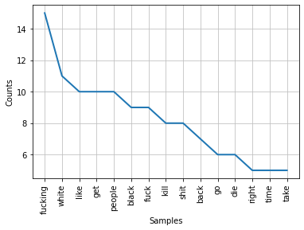

```python
###Frequency of violent and directed

words = nltk.word_tokenize(cleanedwords)
words = [w for w in words]
fq = nltk.FreqDist(w for w in words if w.isalnum())
fq.plot(15)
```

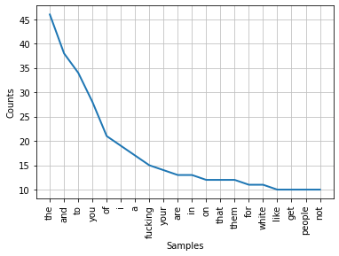

```python
words = nltk.word_tokenize(lst)
words = [w for w in words]
fq = nltk.FreqDist(w for w in words if w.isalnum())
fq.plot(20)
```

```python
rslur=[]
for x in range(len(words)):
    rslur.append(words[x]==('black') or words[x]==('the'))
rslur
```

[output not shown]

[output cut: 946 more lines]

```
 False,
 False,
 False,
 False,
 False,
 False,
 False,
 False,
 False,
 False,
 False,
 False,
 False,
 False,
 ...]
```

```python
#'niggers' or 'nigger' or 'nig' or 'nigs' or 'coon' or 'niglet' or 'black' or 'blacks'
```

[output not shown]

Racial/ethnic slurs: https://en.wikipedia.org/wiki/List_of_ethnic_slurs https://en.wikipedia.org/wiki/List_of_ethnic_slurs_and_epithets_by_ethnicity https://onlinelibrary.wiley.com/doi/abs/10.1002/9781405165518.wbeoss126 http://www.rsdb.org/full

Hispanic/Latino slurs: "The hispanics" 4 times "The Mexicans" 4 times "spic" 4 times "Beaner" 3 times "wetback"2 times

Middle Eastern/Muslim: "The mulsims" 2 times "Paki/pakki"

Asian slurs: "The asians" 4 times "yellow" in reference to asian people 10 times "chinamen/chinaman" 2 times "Mongrel" 10 times "chinky"

Anti-White slurs: "cracker" 0 times "honky" 0 times "Whitey" is used many times, but almost entirely self referential

Limitations: Some of the text appears corrupted. with odd symbols. Retweats may be double counted astericks and misspellings There are slurs that we do not know